# GridModificationExample

Christopher Dory

2025-07-17

# Variable documentation

**out_dir**: string with forward slashes, describes where to save files  
**out_name**: string with no ‘.’ extension, describes name to give to output files  
**shapefile**: Anything with a ‘geometry’ column. Describes a shapefile to intersect with model grid  
**model_grid**: Anything with a ‘geometry’ column and column of ID values for the grid. Describes polygons of model grid (5 vertices)[v1,v2,v3,v4,v1]  
**cell_area**: numeric value [m^2] describing the area of each cell. Used when calculating what percent of cell is intersected by shapefile.  
**hru_id_column**: numeric, describes what column number in the model_grid to find the IDs of the grid cells  
**replacement_value**: numeric, describes a single number to replace the starting values with  
**starting_values**: either SpatRaster, RasterLayer, or vector. length of vector or number of raster cells must be equal to number of model grid cells.Describes the starting cell values to modify  
**export_as_grid**: boolean, describes whether to export results as a ‘.tif’ raster  
**export_long_format**: boolean, describes whether to export results as a two column csv (ID,Values)  
**is_raster**: boolean, describes whether the starting_values is a raster or a vector  
**grid_dims**: vector of numeric, described in c(rows, columns) the dimensions of the model grid  
**null_value**: describes the value to give cells with no intersection with the shape file if no starting values are supplied  
**engulf**: boolean, describes whether model gridcells need to be completly covered by shapefile in order for their values to be updated  
**partial_fact**: numeric range 0-100, describes above what percentage the cell needs to be covered in order to have its values updated if engulf == FALSE  
**scale_by_intersected_area**: boolean, if false all cells above partial_fact coverage will be set to the replacement value. If true all cells above partial fact will have value scaled between starting and replacement value based on how much of cell is covered  
**example**: boolean, if running example code set to true, else set to false

# Starting Conditions

This displays an example grid with an irregular shapefile overlaid onto it.  
The grid starts with initial values of 1 for each cell, which we want to modify if they intersect with the shapefile

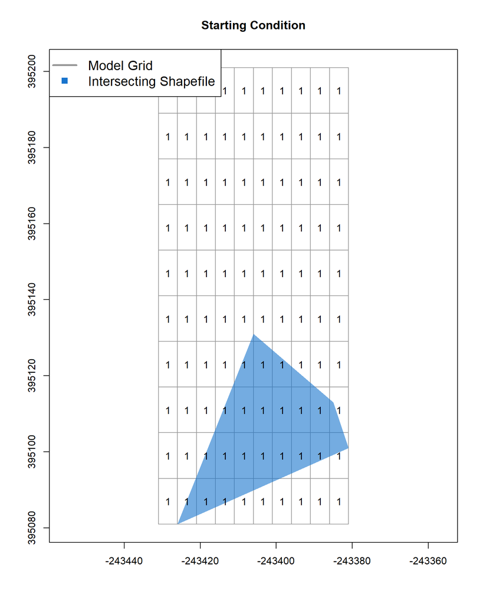

# Function Example

In this case the user wants to replace the 1 values with 3. Values should be replaced if cells have greater than 10% (‘partial_fact’) of their area overlapped by the shapefile, with their new value scaled by the amount overlapped (‘scale_by_intersected_area’). For example a cell 10% overlapped would have 10% of the distance between 1 and 3 (0.2) added to its starting value for a final value of 1.2.

```r
# -------------------------------------------------------------------------------------
# Run function
Attribute_Grid_By_SHP(out_dir = '',
                      out_name = '',
                      shapefile = polygon,
                      model_grid = grid,
                      hru_id_column = 1,
                      replacement_value = 3,
                      starting_values = rep(1,100),
                      export_as_grid = TRUE,
                      export_long_format = TRUE,
                      is_raster = FALSE,
                      grid_dims = c(10,10),
                      null_value = 0,
                      engulf = FALSE,
                      partial_fact = 10,
                      scale_by_intersected_area = TRUE,
                      example = TRUE)
# -------------------------------------------------------------------------------------
```

# Result of Grid Update

This shows the new values of the grid

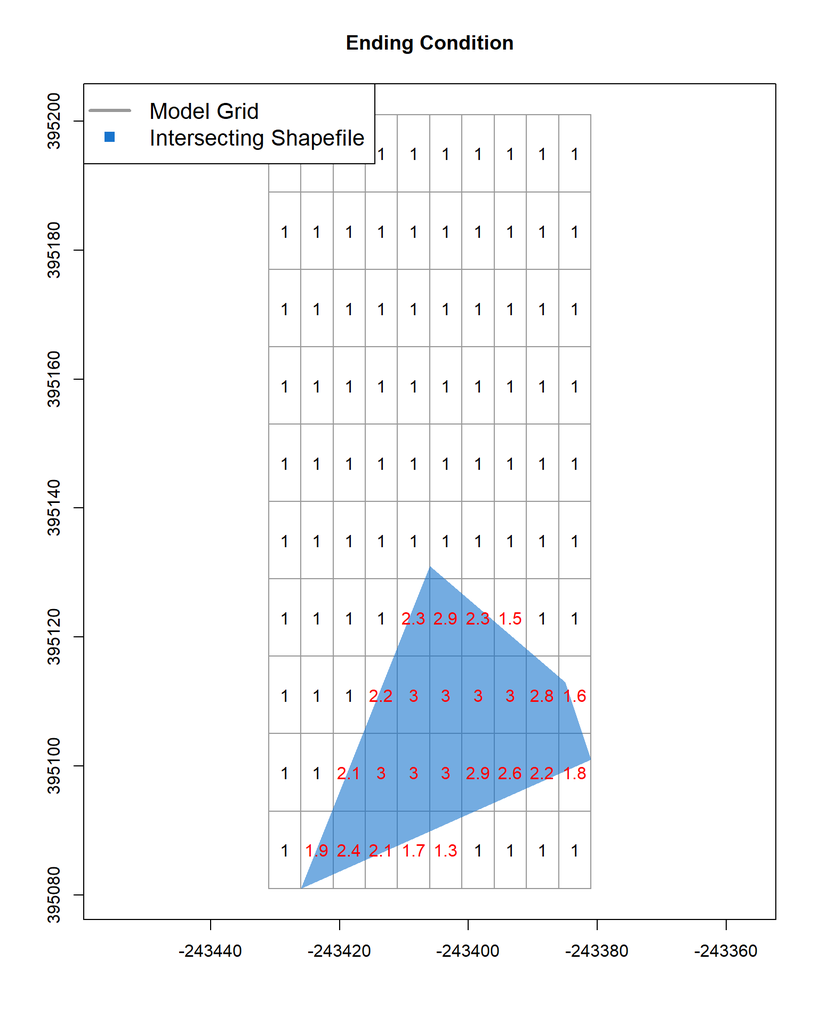

# Export as Raster

The code can also export the modified grid as a raster format (.tif)

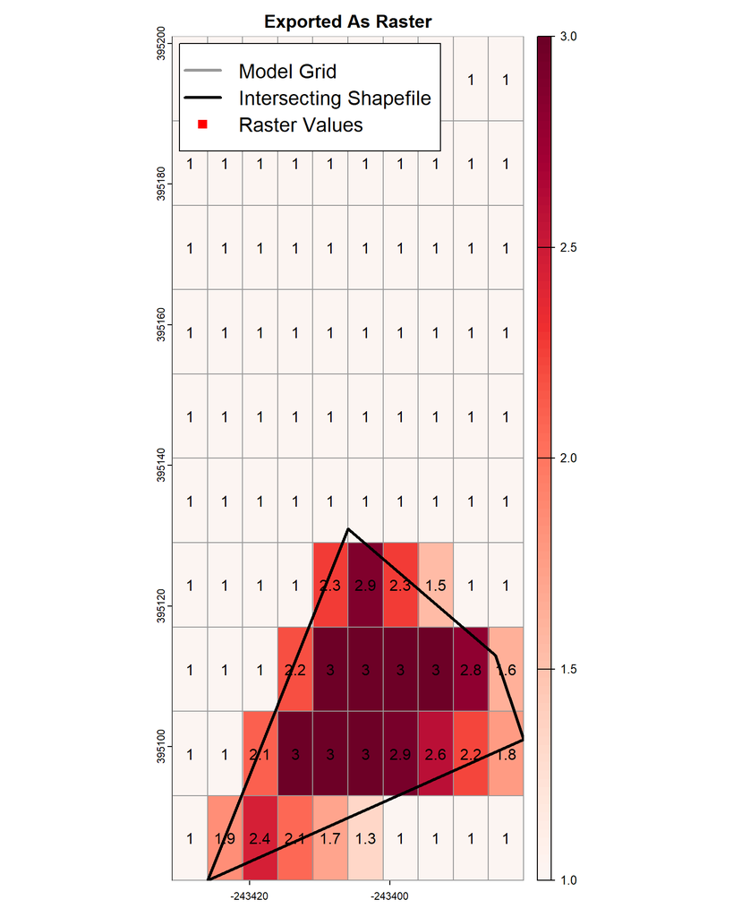

# Function Example 2

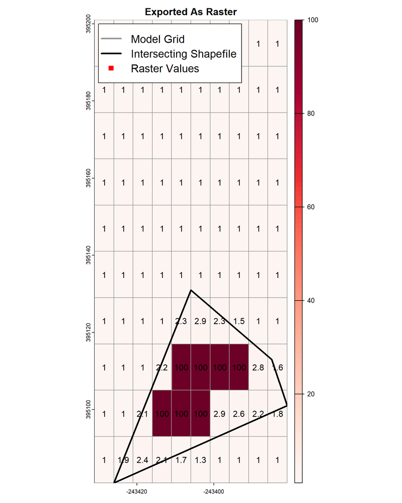

```r
# -------------------------------------------------------------------------------------
# Run function
Attribute_Grid_By_SHP(out_dir = '',
                      out_name = '',
                      shapefile = polygon,
                      model_grid = grid,
                      hru_id_column = 1,
                      replacement_value = 100,
                      starting_values = raster_example,
                      export_as_grid = TRUE,
                      export_long_format = TRUE,
                      is_raster = TRUE,
                      grid_dims = c(10,10),
                      null_value = 0,
                      engulf = TRUE,
                      partial_fact = NULL,
                      scale_by_intersected_area = FALSE,
                      example = TRUE)
# -------------------------------------------------------------------------------------
```